# Maximum Likelihood & Optimisation

Matthew Talluto

24.11.2023

# What is a likelihood?

- In the Zombie example, we knew the probability of being a zombie: $p_z = 0.3$
- We wanted to know the probability of observing some number of zombies $k$ in a sample of $n=10$
- More typically, we would observe $k$ and $n$ via *sampling*, and want to estimate $p_z$.

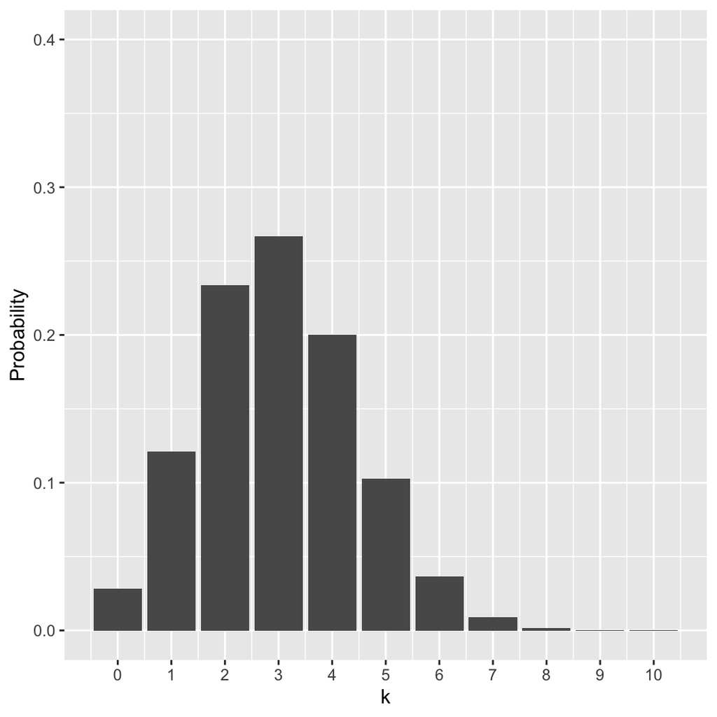

# Sampling a population

- We sampled a large population to determine the rate of zombism.
- Assume samples were random, *iid*
- Given a sample of $n=25$, we observed $k=7$ zombies.
- Estimate $p_z$, the proportion of the population that is a zombie.

# Sampling a population

- We sampled a large population to determine the rate of zombism.
- Assume samples were random, *iid*
- Given a sample of $n=25$, we observed $k=7$ zombies.
- Estimate $p_z$, the proportion of the population that is a zombie.
- **Use intuition:** We know the best estimate is $p_z = 7/25 = 0.28$. Why?

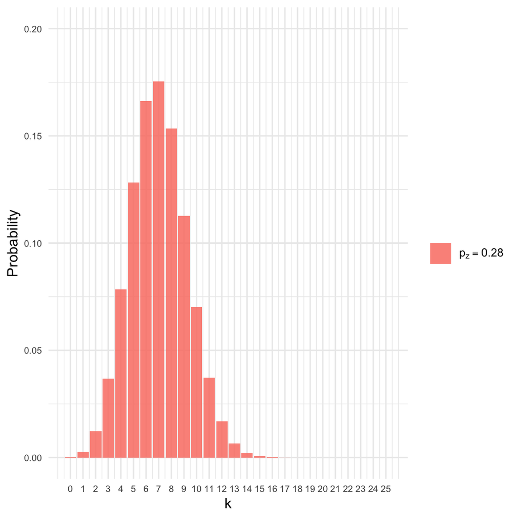

# Sampling a population

- We sampled a large population to determine the rate of zombism.
- Assume samples were random, *iid*
- Given a sample of $n=25$, we observed $k=7$ zombies.
- Estimate $p_z$, the proportion of the population that is a zombie.
- **Use intuition:** We know the best estimate is $p_z = 7/25 = 0.28$. Why?
- Many other values of $p_z$ are also possible.

# Parameter estimation

- We need a general method for **parameter estimation**
- In this case, want to estimate $p_z$
- Understanding the **uncertainty** in our estimate would also be nice

# The likelihood model

- If I *assume* a model $\theta$…
- Can I compute the probability that the data came from this model?

# The likelihood model

- If I *assume* a model $\theta$…
- Can I compute the probability that the data came from this model?

$pr(\mathrm{Data} | \theta)$

# The likelihood model

- Example: $\theta = p_z$
- Assume $\hat{p}_z = 0.4$
- What is the probability that the data ($k = 7, n = 25$) if this model is true?

# The likelihood model

- Example: $\theta = p_z$
- Assume $\hat{p}_z = 0.4$
- What is the probability that the data ($k = 7, n = 25$) if this model is true?

$pr(k=7,n=25 | p_z = 0.4) = ?$

Any guesses how?

# The likelihood model

- We already described this system with a **binomial process**
- This is a **generative model**: we describe the statistical process (a binomial process with p = 0.4) that produces the observed data.
- We can evaluate it with built-in functions in R

# The likelihood model

- We already described this system with a **binomial process**
- This is a **generative model**: we describe the statistical process (a binomial process with p = 0.4) that produces the observed data.
- We can evaluate it with built-in functions in R

```r
# x is observation, in this case, k = 7
# size is n, the number of trials
# prob is the model parameter
dbinom(x = 7, size = 25, prob = 0.4)
```

```
## [1] 0.07998648
```

# The likelihood model

```r
# x is observation, in this case, k = 7
# size is n, the number of trials
# prob is the model parameter
dbinom(x = 7, size = 25, prob = 0.4)
```

```
## [1] 0.07998648
```

We can try another model to see if it’s better:

```r
dbinom(x = 7, size = 25, prob = 0.2)
```

```
## [1] 0.1108419
```

# The likelihood model

```r
# x is observation, in this case, k = 7
# size is n, the number of trials
# prob is the model parameter
dbinom(x = 7, size = 25, prob = 0.4)
```

```
## [1] 0.07998648
```

We can try another model to see if it’s better:

```r
dbinom(x = 7, size = 25, prob = 0.2)
```

```
## [1] 0.1108419
```

And we can plot it against many different potential models

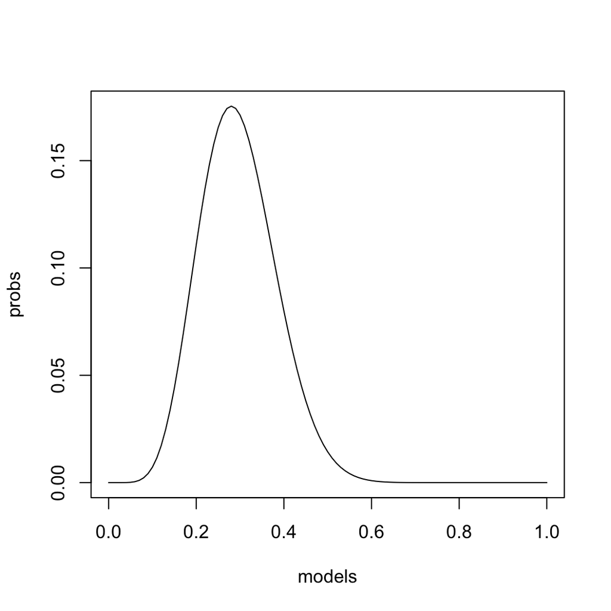

```r
# different potential values for p, which must be between 0 and 1
models = seq(0, 1, 0.01)
probs = dbinom(x = 7, size = 25, prob = models)
plot(models, probs, type = 'l')
```

# Likelihood functions

- The **likelihood function** is a function *f* of the data $X$ and model/parameters $\theta$
- Here $X = \{k,n\}$ and $\theta = \{p_z\}$
- $f(X,\theta)$ returns the *probability of observing* $X$, given a particular model $\theta$: $pr(X|\theta)$
- Here, the *binomial PMF* is a useful likelihood function

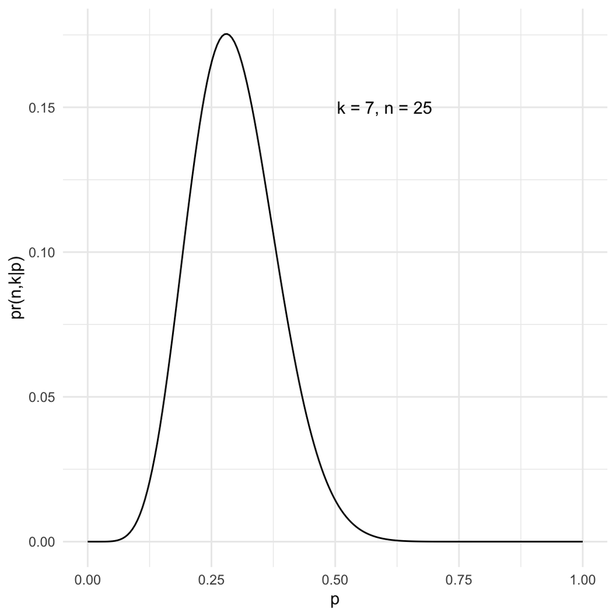

# Likelihood functions

- Intuition is fine, but how do we estimate or (in some cases) solve for the maximum likelihood? Guessing might take a long time!
- $n=25$, $k=7$

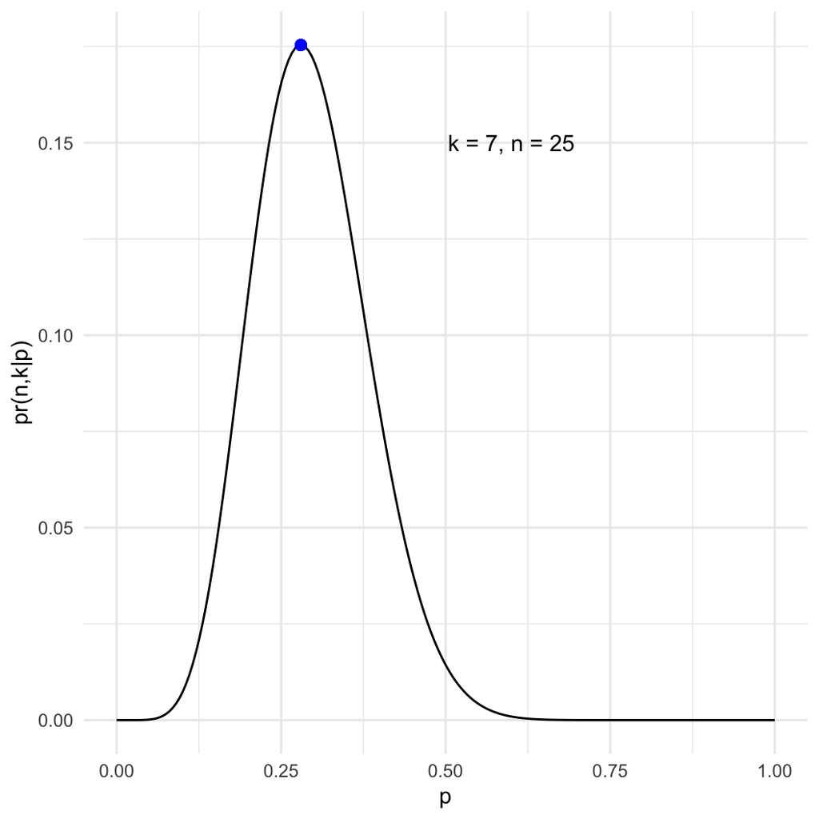

# Solving for the MLE

$$\begin{aligned}
\mathcal{L}(k,n|p) & = {n \choose k} p^k(1-p)^{(n-k)} \\
\frac{d \mathcal{L}(k,n|p)}{dp} & = {n \choose
k}kp^{k-1}(1-p)^{(n-k)} - {n \choose k} p^k (n-k)(1-p)^{(n-k-1)} \\
& = 0
\end{aligned}$$

# Solving for the MLE

$$\begin{aligned}
{n \choose k} p^k (n-k)(1-p)^{(n-k-1)} & = {n \choose
k}kp^{k-1}(1-p)^{(n-k)} \\
p(p^{k-1}) (n-k)(1-p)^{(n-k-1)} & = kp^{k-1}(1-p)(1-p)^{(n-k-1)} \\
p (n-k) & = k(1-p) \\
pn -pk & = k-pk \\
pn & = k \\
p & = \frac{k}{n} \\
\end{aligned}$$

# Optimisation

- In many (most) cases, analytical solutions are unavailable or impractical.
- We turn to various algorithms for numerical optimisation

# Optimisation

- In many (most) cases, analytical solutions are unavailable or impractical.
- We turn to various algorithms for numerical optimisation

```r
n = 25
k = 7
llfun = function(p, n, k) {
  dbinom(k, n, p, log=TRUE) ## why log??
}
p_init = 0.5
optim(p_init, llfun, method = "Brent", n = n, k = k, control = list(fnscale = -1), lower=0, upper=1)
```

```
## $par
## [1] 0.28
##
## $value
## [1] -1.740834
##
## $counts
## function gradient
##       NA       NA
##
## $convergence
## [1] 0
##
## $message
## NULL
```

# Generalising to multiple observations

- Remember the product rule: for two independent events, $pr(A,B) = pr(A)pr(B)$
- Likelihoods are probabilities, and we like to assume each data point is independent. Thus:

$$\begin{array}
\mathcal{L}(X_{1..n}|\theta) & = \prod_{i=1}^{n}
\mathcal{L}(X_i|\theta) \\
& \mathrm{or} \\
\log \mathcal{L}(X_{1..n}|\theta) &= \sum_{i=1}^{n} \log
\mathcal{L}(X_i|\theta)
\end{array}$$

```r
# define our data set
n_vec = c(25, 12, 134)
k_vec = c(7, 4, 27)

# write a custom function that returns the log likelihood
llfun = function(p, n, k) {
  sum(dbinom(k, n, p, log=TRUE)) ## why log?? why sum??
}

# we need an initial guess for the parameter we want to optimise
p_init = 0.5
```

```r
# optim will start at p_init, evaluate llfun using the data we pass
# and return the optimum (if found)
# the terms n = ... and k = ... must be named the way they are in llfun
optim(p_init, llfun, method = "Brent", n = n_vec, k = k_vec,
      control = list(fnscale = -1), lower=0, upper=1)
```

```
## $par
## [1] 0.2222222
##
## $value
## [1] -6.419546
##
## $counts
## function gradient
##       NA       NA
##
## $convergence
## [1] 0
##
## $message
## NULL
```

# Parameter estimation in Stan

- Stan is a modelling language for scientific computing
- Stan is a *probabilistic programming language*
  - deterministic variables: `a = b * c`
  - Stochastic variables: `y ~ normal(mu, sigma)`

### Workflow

1. Write a Stan model in a `.stan` file
2. Prepare all data in R
3. Use the `rstan` package to invoke the Stan interpreter
   - Translates your model into a C++ program w/ an HMC sampler, then compiles for your computer
4. Run the program from R using functions in the `rstan` package.

# Parameter estimation in Stan

- Comments in Stan use the `//` characters

```stan
// Saved in vu_advstats_students/stan/zomb_p.stan
```

# Parameter estimation in Stan

- All Stan programs need a `data` block where you define any input data for your model
  - Variables must have a **type**
  - Here, `int` indicates a variable that is an integer
  - **Constraints** give rules about variables; here k must be positive, and n >= k

```stan
// Saved in vu_advstats_students/stan/zomb_p.stan
data {
    int <lower = 0> k;
    int <lower = k> n;
}
```

# Parameter estimation in Stan

- In the `parameters` block, we define **unknowns** that we want to estimate
  - `p` is a real number between 0 and 1

```stan
// Saved in vu_advstats_students/stan/zomb_p.stan
data {
    int <lower = 0> k;
    int <lower = k> n;
}
parameters {
    real <lower = 0, upper = 1> p;
}
```

# Parameter estimation in Stan

- In the `model` block we specify our likelihood function
  - `k` comes from a binomial distribution with probability `p` and `n` observations

```stan
// Saved in vu_advstats_students/stan/zomb_p.stan
data {
    int <lower = 0> k;
    int <lower = k> n;
}
parameters {
    real <lower = 0, upper = 1> p;
}
model {
    k ~ binomial(n, p);
}
```

# Parameter estimation in Stan

- In R, we load the `rstan` package
- Next we **compile** the model using `stan_model`
  - Compiled models don’t need to be re-compiled unless the code in the .stan file changes!

```r
# assuming working directory is vu_advstats_students
library(rstan)
zomb_p = stan_model("stan/zomb_p.stan")
```

# Parameter estimation in Stan

- We next create a data list that we will pass on to Stan
- Finally, we can use `optimizing`, which works similar to `optim` but for Stan models

```r
# assuming working directory is vu_advstats_students
library(rstan)
# zomb_p = stan_model("stan/zomb_p.stan") # already did this, don't do it twice

# names must match the data block in Stan
zomb_data = list(n = 25, k = 7)
optimizing(zomb_p, data = zomb_data)
```

```
## $par
##         p
## 0.2800159
##
## $value
## [1] -14.82383
##
## $return_code
## [1] 0
##
## $theta_tilde
##              p
## [1,] 0.2800159
```

# Why Bayes?

- I want to describe some phenomenon (“model”; $\theta$)
- I have some general (“prior”) knowledge about the question: $pr(\theta)$
- I gather additional information (“data”; $X$)

What is the probability that my model is correct given what I already know about it and what I’ve learned?

$$pr(\theta | X)$$

# Applying Bayes’ Theorem

- We already know an expression for this:

$$pr(\theta | X) = \frac{pr(X|\theta)pr(\theta)}{pr(X)}$$

# Applying Bayes’ Theorem

- We already know an expression for this:

$$pr(\theta | X) = \frac{pr(X|\theta)pr(\theta)}{pr(X)}$$

- The goal, $pr(\theta | X)$, is called the **posterior probability of $\theta$**
- We have already seen $pr(X|\theta)$; this is the **likelihood** of the data
- $pr(\theta)$ is often called the **prior probability of $\theta$**. Could also be called “other information about $\theta$”
- What about $pr(X)$? This is the **normalizing constant**

When we do Bayesian inference, each of these terms is a full **probability distribution**

# The normalizing constant

- For the first zombie problem, we had a single observation (“I tested positive”), we were able to add up all of the ways one could test positive.
- $pr(T) = pr(T,Z) + pr(T,Z') = pr(T|Z)pr(Z) + pr(T|Z')pr(Z')$
- $pr(X) = \sum_i^n pr(X|\theta_i)pr(\theta_i)$ where all possible models are in the set $n$
- What about for continuous problems?

# The normalizing constant

- For the first zombie problem, we had a single observation (“I tested positive”), we were able to add up all of the ways one could test positive.
- $pr(T) = pr(T,Z) + pr(T,Z') = pr(T|Z)pr(Z) + pr(T|Z')pr(Z')$
- $pr(X) = \sum_i^n pr(X|\theta_i)pr(\theta_i)$ where all possible models are in the set $n$
- What about for continuous problems?
  - There are an infinite number of possible models if $pr(\theta)$ is a continuous PDF.
  - There are infinitely many possible datasets if X is real-valued

# The normalizing constant

- For the first zombie problem, we had a single observation (“I tested positive”), we were able to add up all of the ways one could test positive.
- $pr(T) = pr(T,Z) + pr(T,Z') = pr(T|Z)pr(Z) + pr(T|Z')pr(Z')$
- $pr(X) = \sum_i^n pr(X|\theta_i)pr(\theta_i)$ where all possible models are in the set $n$
- What about for continuous problems?
  - There are an infinite number of possible models if $pr(\theta)$ is a continuous PDF.
  - There are infinitely many possible datasets if X is real-valued

$$pr(X) = \int_a^b pr(X|\theta)pr(\theta)d \theta$$

- This integral can be challenging to compute

# Proportional Bayes’ Theorem

- $pr(X)$ is a *constant*; it adjusts the height of the distribution so that the posterior integrates to 1
- If all we want to do is estimate the maximum value, we can safely ignore it

# Proportional Bayes’ Theorem

- $pr(X)$ is a *constant*; it adjusts the height of the distribution so that the posterior integrates to 1
- If all we want to do is estimate the maximum value, we can safely ignore it

$$pr(\theta|X) \propto pr(X|\theta)pr(\theta)$$

- For our example, we used the binomial PMF for the likelihood:

$$pr(X|\theta) = pr(k,n|p) = {n \choose k} p^k(1-p)^{(n-k)}$$

How to choose the prior, $pr(\theta)$?

# What do we know about p?

- Must be between 0 and 1.
- We could assign equal probabilities using a uniform distribution:

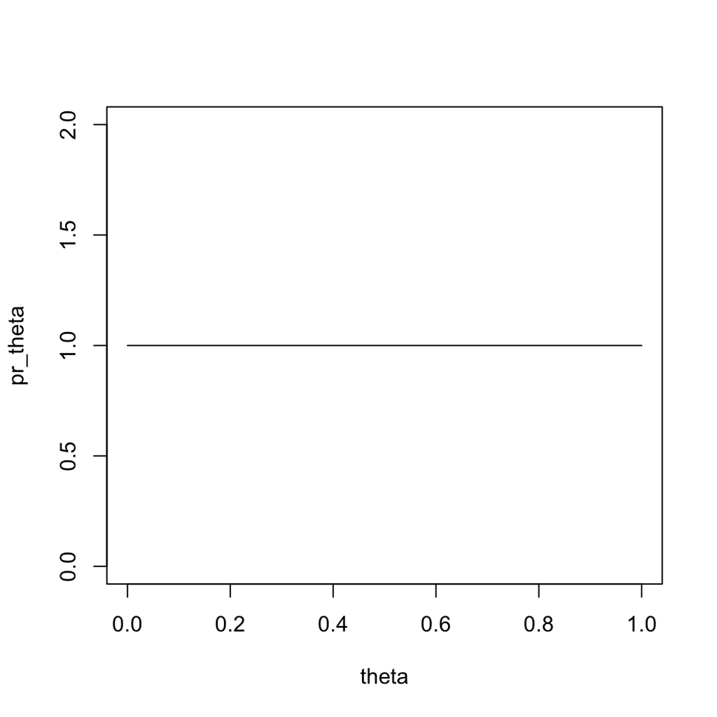

```r
theta = seq(0, 1, 0.01)
pr_theta = dunif(theta, min = 0, max = 1)
plot(theta, pr_theta, type = 'l')
```

# What do we know about p?

- Must be between 0 and 1.
- We could assign equal probabilities using a uniform distribution.
- Not very flexible. Maybe we think central values are slightly more likely?
- A **beta** distribution makes many shapes possible

```r
theta = seq(0, 1, 0.01)
pr_theta_1 = dbeta(theta, shape1 = 1, shape2 = 1)
```

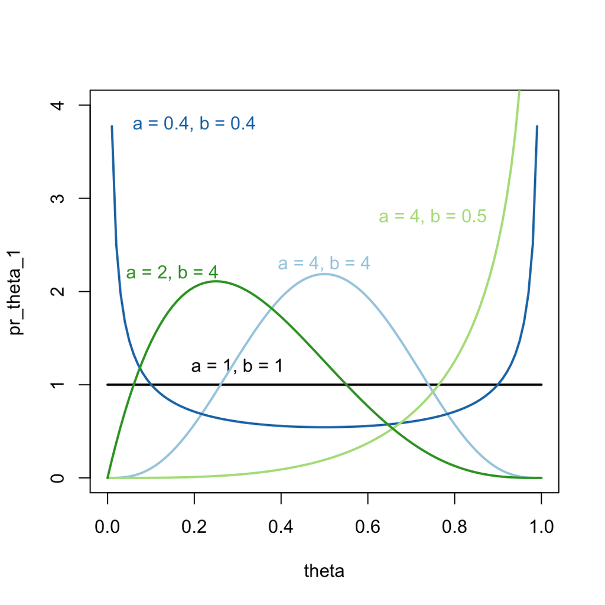

# Maximum A Posteriori Estimation

- If we just want a Bayesian point estimate for $\theta$, we can use the same algorithms for MLE
- This is know as the **maximum a posteriori** (MAP) estimate, Bayesian equivalent to the MLE
- We ignore the normalising constant and incorporate a prior into the methods we used before

```r
log_liklihood = function(p, n, k)
  sum(dbinom(k, n, p, log=TRUE))

log_prior = function(p, a, b)
  dbeta(p, a, b, log = TRUE)

log_posterior = function(p, n, k, a, b)
  log_liklihood(p, n, k) + log_prior(p, a, b)
```

```stan
// Saved in vu_advstats_students/stan/zomb_p_bayes.stan
data {
    int <lower = 0> k;
    int <lower = k> n;
    real <lower = 0> a;
    real <lower = 0> b;
}
parameters {
    real <lower = 0, upper = 1> p;
}
model {
    k ~ binomial(n, p);
    p ~ beta(a, b);
}
```

# Maximum A Posteriori Estimation

Now we can fit the model, either in R or in Stan

```r
zomb_p_bayes = stan_model("stan/zomb_p_bayes.stan")
```

```r
zomb_data = list(
    n = 25,
    k = 7,
    a = 1, # totally flat prior to start
    b = 1
)

## starting value for the optimisation
p_init = 0.5

optim(p_init, log_posterior, method = "Brent", n = zomb_data$n,
    k = zomb_data$k, a = zomb_data$a, b = zomb_data$b,
    control = list(fnscale = -1), lower=0, upper=1)$par
```

```
## [1] 0.28
```

```r
optimizing(zomb_p_bayes, data = zomb_data)$par
```

```
##         p
## 0.2800134
```

This prior has no influence on the posterior

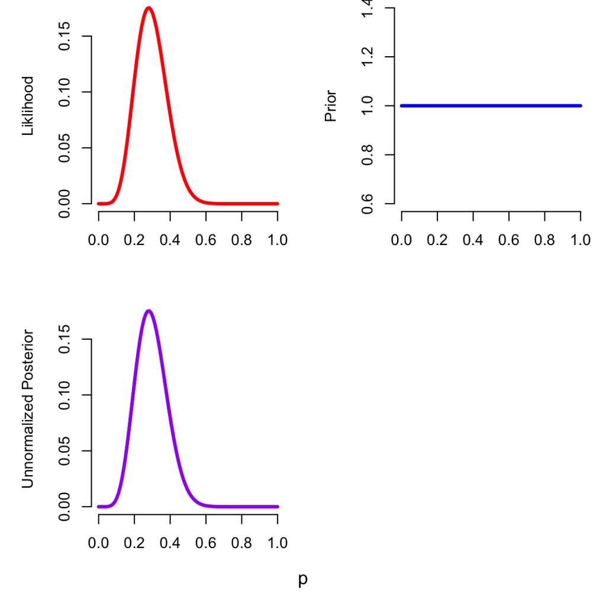

# Changing the prior

```r
zomb_data$a = 2; zomb_data$b = 2
optimizing(zomb_p_bayes, data = zomb_data)$par
```

```
##         p
## 0.2962974
```

```r
zomb_data$a = 3; zomb_data$b = 1.5
optimizing(zomb_p_bayes, data = zomb_data)$par
```

```
##         p
## 0.3272746
```

This prior is informative, but relatively weak (our data has the weight equivalent to `alpha=7, beta=18`)

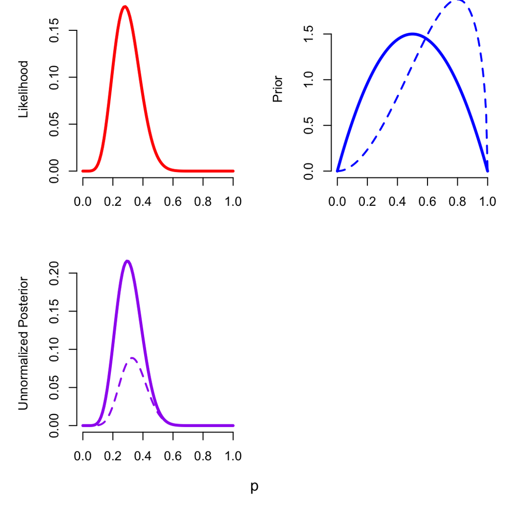

# Changing the prior

What if we had already conducted an identical prior sample, with 20 zombies and 5 normals?

```r
zomb_data$a = 20; zomb_data$b = 5
optimizing(zomb_p_bayes, data = zomb_data)$par
```

```
##         p
## 0.5416666
```

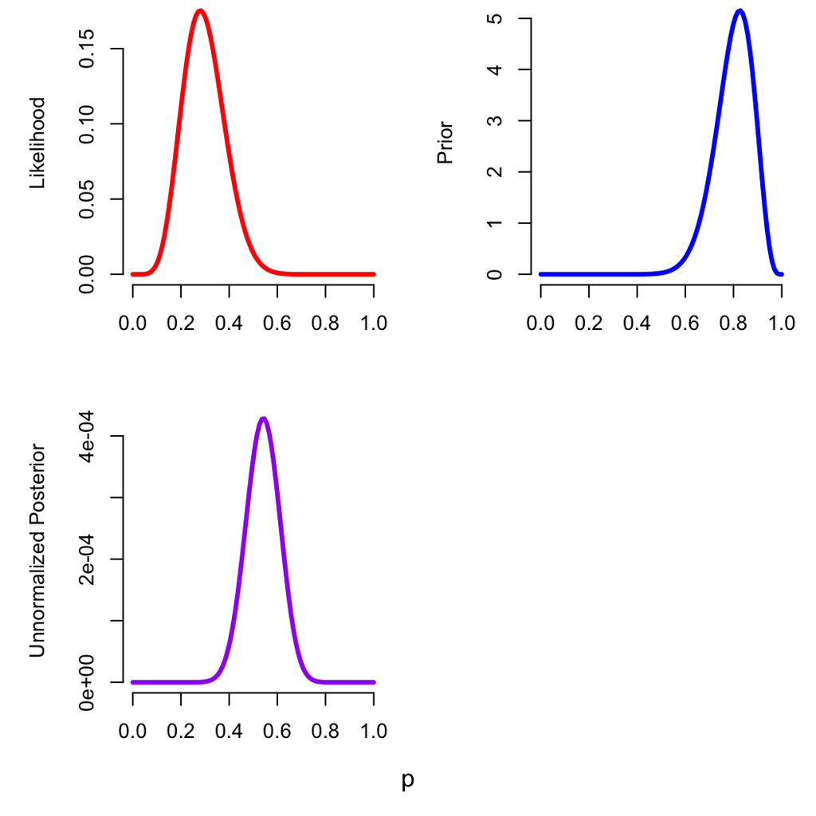

# Geting a normalized posterior

- We often want to know the full posterior distribution
- For some problems, we have analytical solutions to $\int pr(X|\theta)pr(\theta)d \theta$

# Geting a normalized posterior

- We often want to know the full posterior distribution
- For some problems, we have analytical solutions to $\int pr(X|\theta)pr(\theta)d \theta$
- For the beta-binomial, if:

$$\begin{aligned}
pr(p) & = \mathrm{Beta}(a, b) \\
pr(k,n | p) & = \mathrm{Binomial}(k, n, p)
\end{aligned}$$

# Geting a normalized posterior

- We often want to know the full posterior distribution
- For some problems, we have analytical solutions to $\int pr(X|\theta)pr(\theta)d \theta$
- For the beta-binomial, if:

$$\begin{aligned}
pr(p) & = \mathrm{Beta}(a, b) \\
pr(k,n | p) & = \mathrm{Binomial}(k, n, p) \\
pr(p | k,n,\alpha, \beta) &= \mathrm{Beta}(a + k, b + n - k)
\end{aligned}$$

# Geting a normalized posterior

- We often want to know the full posterior distribution
- For some problems, we have analytical solutions to $\int pr(X|\theta)pr(\theta)d \theta$
- In many cases, the shape of the log posterior is appoximately quadratic (the posterior is approximately normal)
- **Laplace approximation** (or Quadratic approximation) is a method for approximating the shape of this curve

# Geting a normalized posterior

- We often want to know the full posterior distribution
- For some problems, we have analytical solutions to $\int pr(X|\theta)pr(\theta)d \theta$
- In many cases, the shape of the log posterior is appoximately quadratic (the posterior is approximately normal)
- **Laplace approximation** (or Quadratic approximation) is a method for approximating the shape of this curve

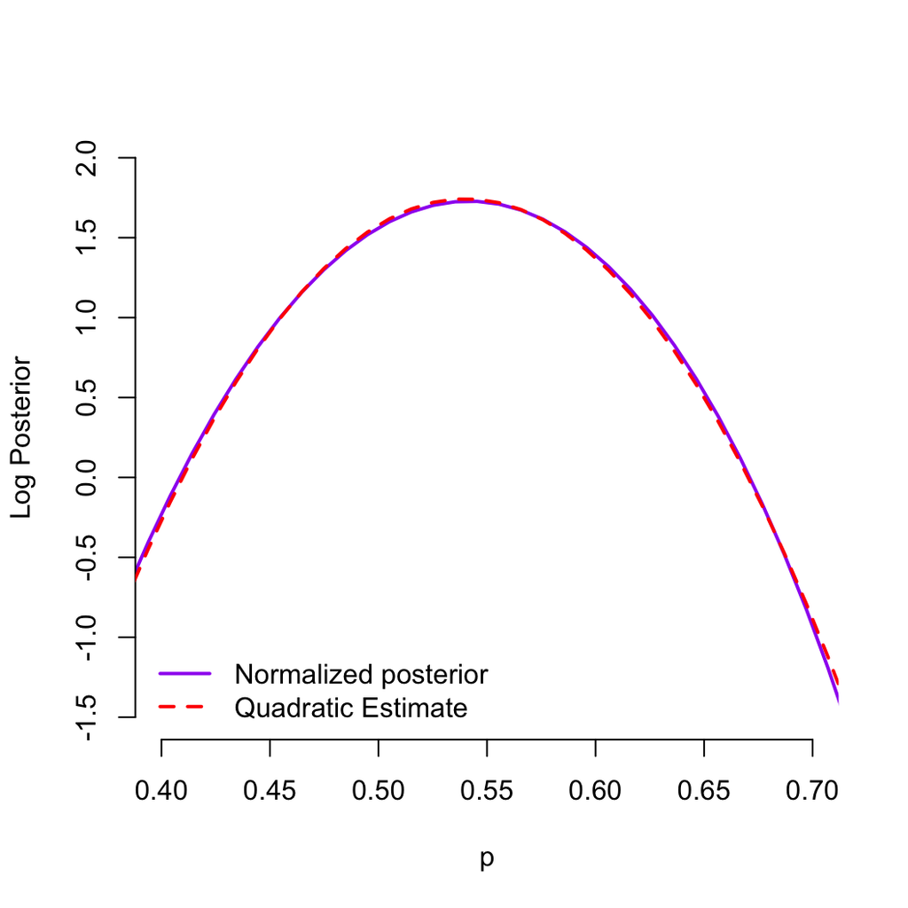

# Geting a normalized posterior

- We often want to know the full posterior distribution
- For some problems, we have analytical solutions to $\int pr(X|\theta)pr(\theta)d \theta$
- In many cases, the shape of the log posterior is appoximately quadratic (the posterior is approximately normal)
- **Laplace approximation** (or Quadratic approximation) is a method for approximating the shape of this curve
- When the above are unavailable, we can use simulations (e.g., MCMC)